# Makeover Monday - Deloitte Christmas Survey 2019

Billy Caughey

12/22/2019

## Introduction

This weeks Makeover Monday is from the Deloitte Christmas Survey 2019. The visual is a representation of the spend in 2018 compared to the spend in 2019. This representation is done in a table with arrows showing the precent change.

This is a nice representation but I am going to try to present the information in a different way. As a statistician, histograms are great methods to use and incorporate. This is because we can can a lot of information in a preceise way.

## Data Import

Again, the folks at data.world have posted the data will an R code to pull the data down to R.

```r
library(httr)
library(readxl)
library(tidyverse)
library(ggplot2)
library(ggpubr)
library(scales)
GET("https://query.data.world/s/yuycdlchnfcjcp35gc4zxzqsfhxduf",
    write_disk(tf <- tempfile(fileext = ".xlsx")))
```

```r
df <- read_excel(tf)
```

The first plot I will make is a barplot showing the amount spent (in pounds) in each category by year. I will use a facet to show the UK and Europe against each other.

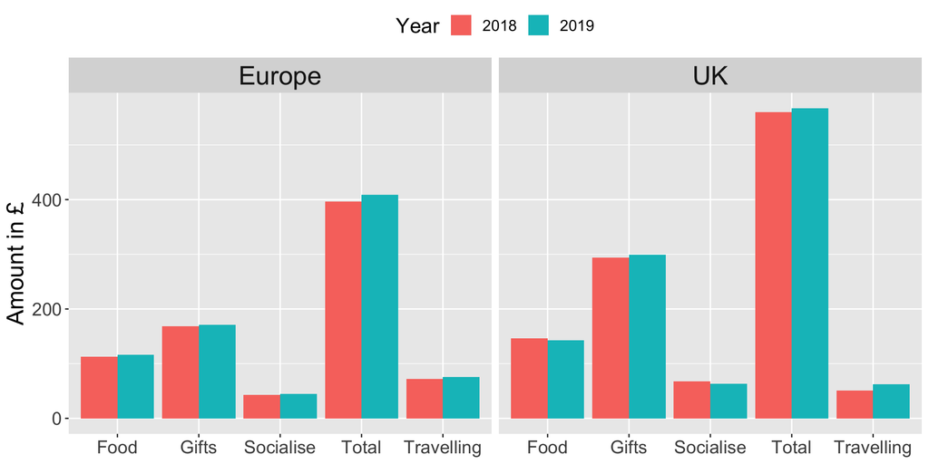

```r
bar1 <- df %>%
    ggplot(aes(x = Category, y = `Amount in £`, fill = as.character(Year))) +
    geom_bar(stat = "identity", position = "dodge") +
    labs(fill = "Year") +
    theme(axis.title.x = element_blank(),
          axis.text.x = element_text(size = 14),
          axis.title.y = element_text(size = 18),
          axis.text.y = element_text(size = 14),
          legend.title = element_text(size = 16),
          legend.text = element_text(size = 12),
          strip.text = element_text(size = 20),
          legend.position = "top") +
    facet_wrap(~ Region, nrow = 1)

bar1
```

The second plot, I will use another barplot. This time, I will do some footwork to compute the percent change from year to year in each category for the UK and Europe. I plot using the same method as the previous plot without use of a facet. This will let me make a percent change for each category within each region.

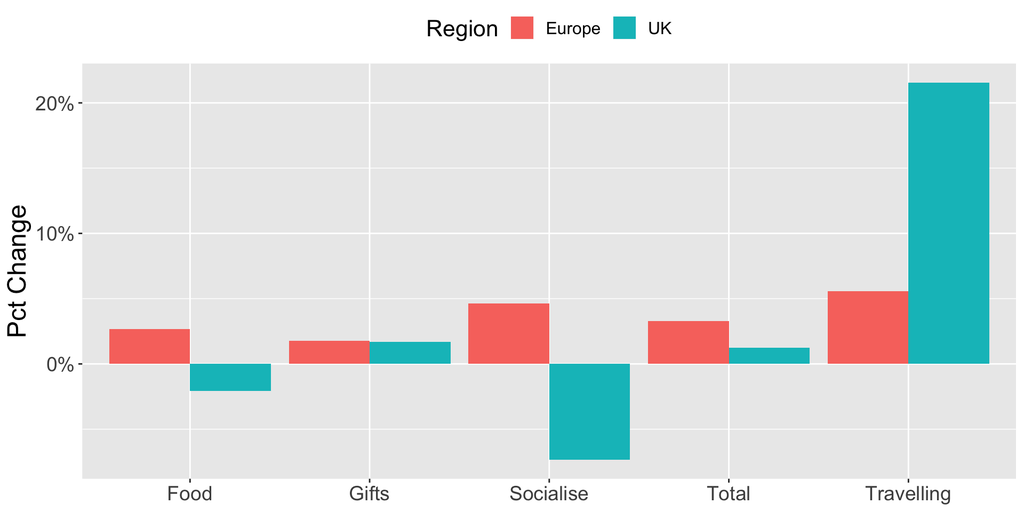

```r
bar2 <- df %>%
    group_by(Region, Category) %>%
    arrange(Year, .by_group = TRUE) %>%
    mutate(`Pct Change` = (`Amount in £`/lag(`Amount in £`)) - 1) %>%
    select(Region, Category, `Pct Change`) %>%
    filter(is.na(`Pct Change`) == FALSE) %>%
    ggplot(aes(x = Category, y = `Pct Change`, fill = Region)) +
    geom_bar(stat = "identity", position = "dodge") +
    theme(axis.title.x = element_blank(),
          axis.text.x = element_text(size = 14),
          axis.title.y = element_text(size = 18),
          axis.text.y = element_text(size = 14),
          legend.title = element_text(size = 16),
          legend.text = element_text(size = 12),
          legend.position = "top") +
    scale_y_continuous(labels = percent)

bar2
```

Finally, I make use of the `ggarrange` function. This function allows the user to combine plots made from the `ggplot` library. A similar method can be found in base R using the `par(mfrow())` method. I should note I change the colors for the year to year comparison. It did not make sense to use the same colors in both charts. In fact, I would argue it makes it difficult to the reader. One additional thing, I use the `theme_bw` option. In my personal opinion, plots look better in `theme_bw`.

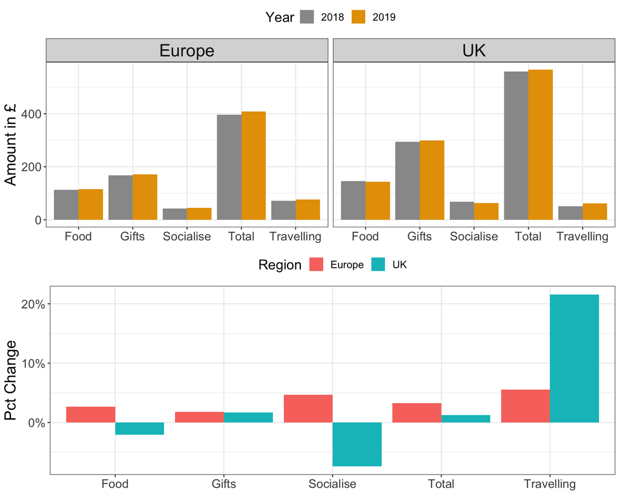

```r
bar1 <- df %>%
    ggplot(aes(x = Category, y = `Amount in £`, fill = as.character(Year))) +
    geom_bar(stat = "identity", position = "dodge") +
    labs(fill = "Year") +
    theme_bw() +
    theme(axis.title.x = element_blank(),
          axis.text.x = element_text(size = 14),
          axis.title.y = element_text(size = 18),
          axis.text.y = element_text(size = 14),
          legend.title = element_text(size = 16),
          legend.text = element_text(size = 12),
          strip.text = element_text(size = 20),
          legend.position = "top") +
    scale_fill_manual(values=c("#999999", "#E69F00")) +
    facet_wrap(~ Region, nrow = 1)

bar2 <- df %>%
    group_by(Region, Category) %>%
    arrange(Year, .by_group = TRUE) %>%
    mutate(`Pct Change` = (`Amount in £`/lag(`Amount in £`)) - 1) %>%
    select(Region, Category, `Pct Change`) %>%
    filter(is.na(`Pct Change`) == FALSE) %>%
    ggplot(aes(x = Category, y = `Pct Change`, fill = Region)) +
    geom_bar(stat = "identity", position = "dodge") +
    theme_bw() +
    theme(axis.title.x = element_blank(),
          axis.text.x = element_text(size = 14),
          axis.title.y = element_text(size = 18),
          axis.text.y = element_text(size = 14),
          legend.title = element_text(size = 16),
          legend.text = element_text(size = 12),
          legend.position = "top") +
    scale_y_continuous(labels = percent)

bar3 <- ggarrange(bar1, bar2, nrow = 2, align = "hv")

bar3
```

This is my submission for this week.

## Data Analysis

Unforunately, the data set is rather small. This does not allow for a statistical analysis at this point. I recommend the reader goes to Deliotte’s survey and read their high level report.